# 04-Data Visualization part 2

Damian Pavlyshyn

Apr 15, 2021

We do the same set-up as in the previous lab.

This time, we use the `read_csv` function instead of `read.csv`. This is the tidyverse version of that function, which produces a tidyverse tibble instead of a base R data frame,

```r
library(tidyverse)
df <- read_csv("http://web.stanford.edu/class/stats32/assets/lecture-3/data/worldbank_data_tidy.csv")
```

As a reminder, the table header is

```r
head(df)
```

```
## # A tibble: 6 x 11
##   cty_name    cty_code  year elecAccess gdpPerCap compEduc educPri educTer
##   <chr>       <chr>    <dbl>      <dbl>     <dbl>    <dbl>   <dbl>   <dbl>
## 1 Afghanistan AFG       2009       45.2     1455.        9      NA      NA
## 2 Afghanistan AFG       2010       42.7     1637.        9      NA      NA
## 3 Afghanistan AFG       2011       43.2     1627.        9      NA      NA
## 4 Afghanistan AFG       2012       69.1     1807.        9      NA      NA
## 5 Afghanistan AFG       2013       70.2     1875.        9      NA      NA
## 6 Afghanistan AFG       2014       89.5     1898.        9      NA      NA
## # ... with 3 more variables: govEducExp <dbl>, popYoung <dbl>, pop <dbl>
```

# Overlaying multiple plots

In the previous lab, we saw the following two plots :

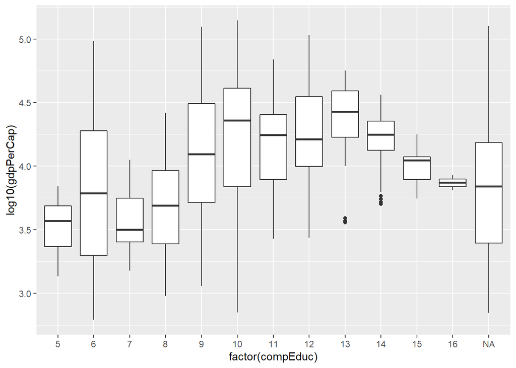

```r
ggplot(data = df, aes(x = factor(compEduc), y = log10(gdpPerCap))) +
    geom_boxplot()
```

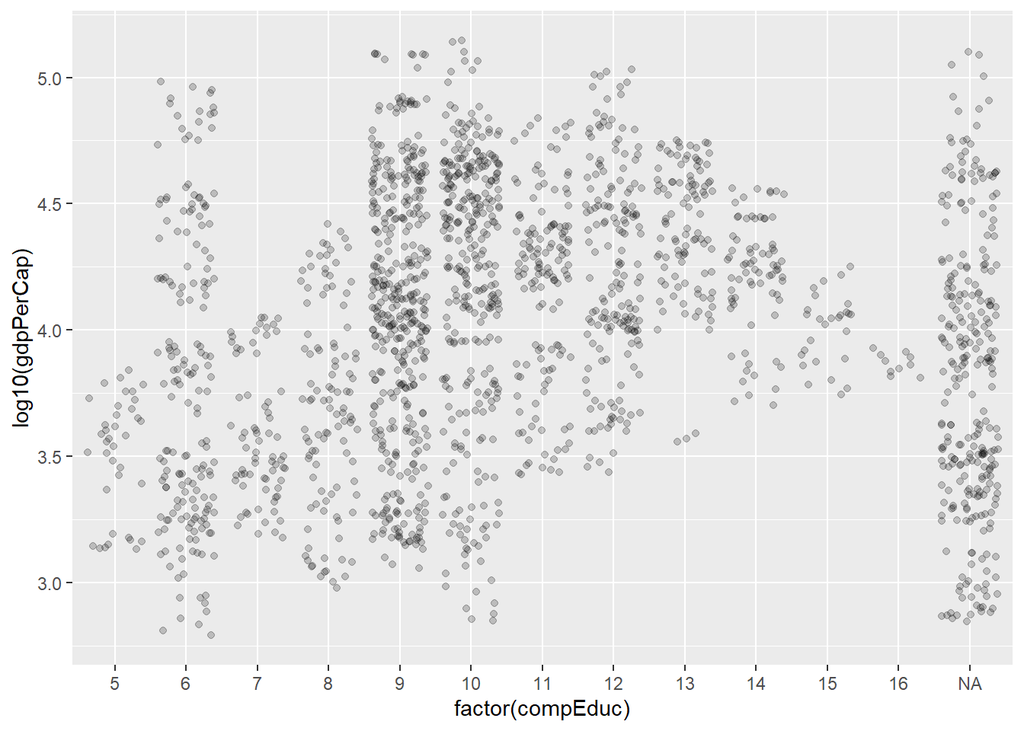

```r
ggplot(data = df, aes(x = factor(compEduc), y = log10(gdpPerCap))) +
    geom_point(alpha = 0.2, position = "jitter")
```

which present the same data.

The boxplots quickly convey a summary of the data, whereas the jittered scatterplot shows all the data - albeit in a bit of a messy way.

To get the strengths of both of these plots, we might want to see them overlaid over each other, plotted on the same axes.

`ggplot` is very good at this kind of thing, and we can accomplish it just by adding both the `geom_boxplot()` and `geom_point()` layers to the same base plot.

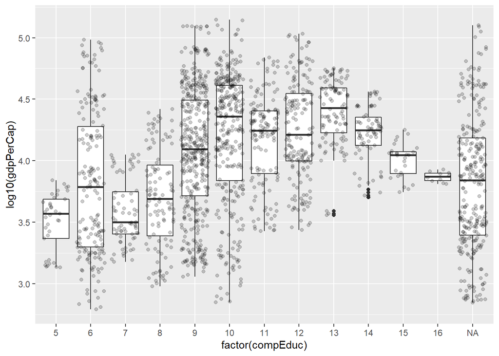

```r
ggplot(data = df, aes(x = factor(compEduc), y = log10(gdpPerCap))) +
    geom_boxplot() +
    geom_point(alpha = 0.2, position = "jitter")
```

The order of the layers is important, as later layers are drawn on top of earlier ones:

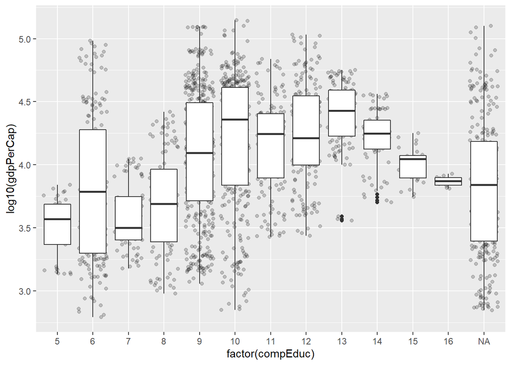

```r
ggplot(data = df, aes(x = factor(compEduc), y = log10(gdpPerCap))) +
    geom_point(alpha = 0.2, position = "jitter") +
    geom_boxplot()
```

Any variable assignment done by an `aes()` function in the base `ggplot()` function gets inherited by each of the `geom_` layers added to the canvas

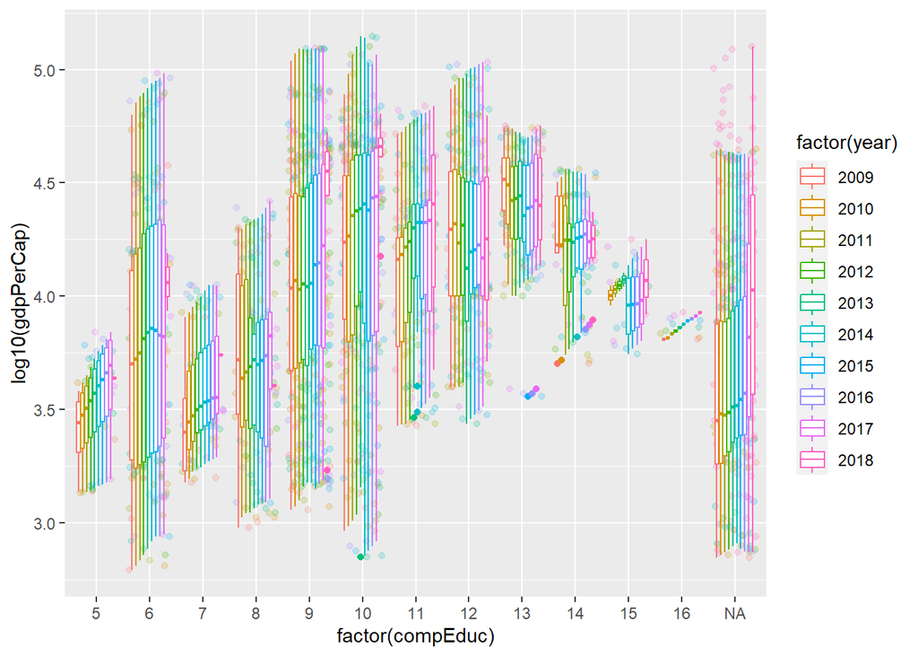

```r
ggplot(data = df, aes(x = factor(compEduc), y = log10(gdpPerCap), color = factor(year))) +
    geom_point(alpha = 0.2, position = "jitter") +
    geom_boxplot()
```

We may not want this, however — the boxplots in the above graph are way to skinny and hard to read, whereas for the scatterplot, the colors seem ok.

To address this, we can assign variables to specific `geom_` layers by including the `aes()` specification for those variables in the `geom_` function rather than in the `ggplot()` function.

In the following plot, we assign `x` and `y` for all layers, but `color` only for the scatterplot layer.

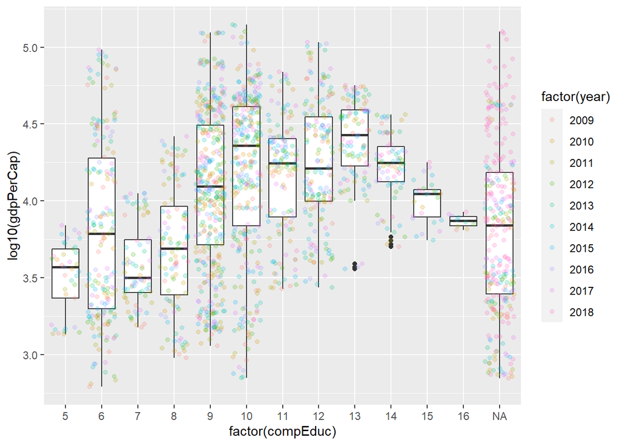

```r
ggplot(data = df, aes(x = factor(compEduc), y = log10(gdpPerCap))) +
    geom_boxplot() +
    geom_point(aes(color = factor(year)), alpha = 0.2, position = "jitter")
```

## Labels and themes

As you know well, it is vital to label your axes! `ggplot` will automatically label each graphical element used (in this case, `x`, `y` and `color`) with the name of that variable in the corresponding data table. However, this is not necessarily human-readable, so the `labs()` function allows us to label the graphical elements with something more evocative.

The `labs()` function also takes an argument named `title`, which does what you would expect - titling the plot.

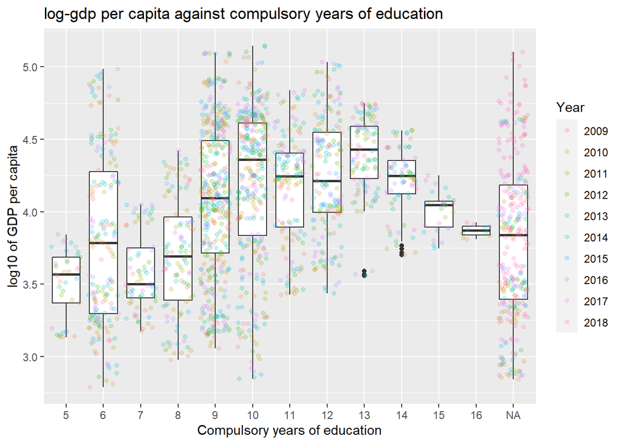

```r
ggplot(data = df, aes(x = factor(compEduc), y = log10(gdpPerCap))) +
    geom_boxplot() +
    geom_point(aes(color = factor(year)), alpha = 0.2, position = "jitter") +
    labs(
        title = "log-gdp per capita against compulsory years of education",
        x = "Compulsory years of education",
        y = "log10 of GDP per capita",
        color = "Year"
    )
```

The plot that we have produced now has all of the right data and labeling, but we can still play around with it to make it look pretty.

The overall look of a plot is dictated by its theme, and this theme is supplied as a layer as any other layer. In the following, we use `theme_bw()` — a personal preference of mine:

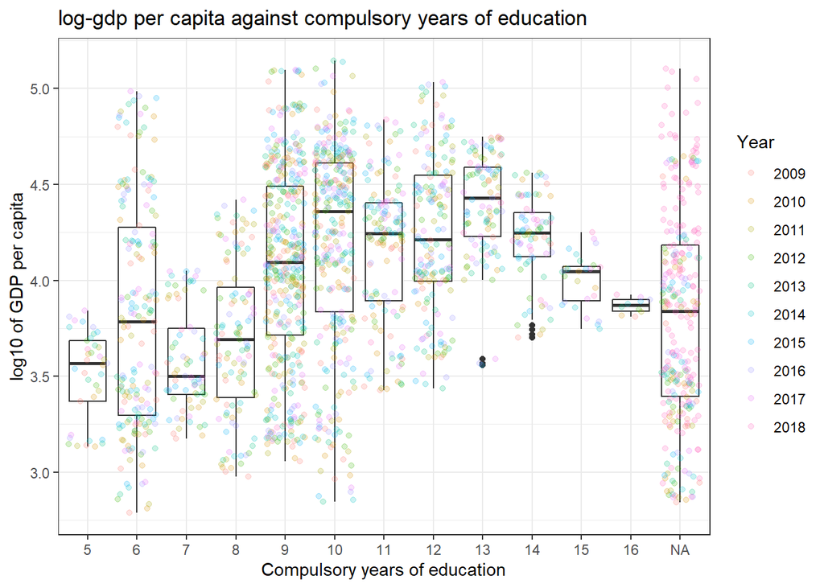

```r
ggplot(data = df, aes(x = factor(compEduc), y = log10(gdpPerCap))) +
    geom_boxplot() +
    geom_point(aes(color = factor(year)), alpha = 0.2, position = "jitter") +
    labs(
        title = "log-gdp per capita against compulsory years of education",
        x = "Compulsory years of education",
        y = "log10 of GDP per capita",
        color = "Year"
    ) +
    theme_bw()
```

There are many themes available — the lecture slides also list `theme_classic()` and `theme_dark()`, but Googling “ggplot themes” will give you all sorts of options.

# Faceting

For the remainder of this lab, we will concentrate on three specific years — 2009, 2013 and 2017.

Recall that to do this, we must create a vector with values `TRUE` at those indices where the corresponding row has one of these years, and `FALSE` everywhere else.

We accomplish this using the `%in%` operator, which checks if a value on its left is contained in the vector on its right. Play around with this operator, and convince yourself that the following command produced the correct vector

```r
df$year %in% c(2009, 2013, 2017)
```

To select the correct rows, we use our usual two-dimensional indexing with this vector:

```r
df_late = df[df$year %in% c(2009, 2013, 2017),]
```

We have seen before how we can use aesthetics like color to distinguish data according to a categorical variable.

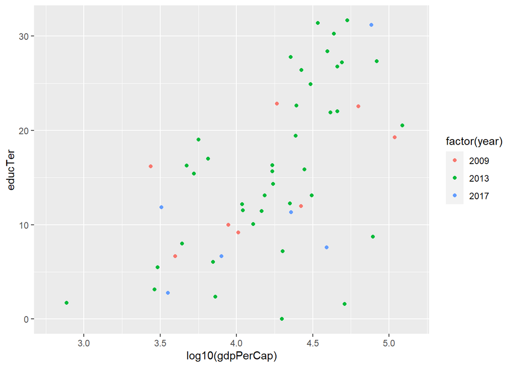

```r
ggplot(data = df_late, mapping = aes(x = log10(gdpPerCap), y = educTer, color = factor(year))) +
    geom_point()
```

There is another way of doing this — namely, we can produce several sub-plots, split according to that categorical variable.

This is done using faceting. Though there are many faceting functions that do slightly different things, the most common is `facet_wrap()`.

In the next plot, we facet by the `factor(year)` variable (remember — in order to facet, we need to ensure that we’re dealing with a categorical variable).

Unfortunately, faceting functions have somewhat strange notation, and we call need to call `facet_wrap(~factor(year))`, making sure note to leave out the `~`. There is a good reason for this notation, related to an R object known as a “formula,” but that is beyond the scope of this course.

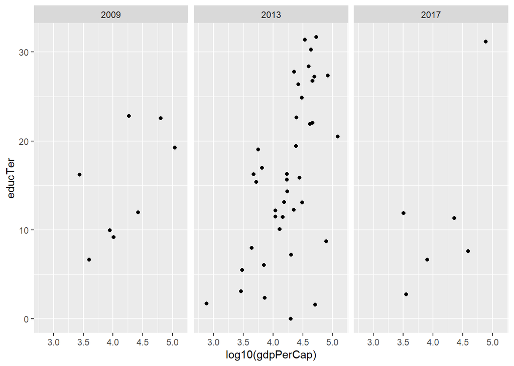

```r
ggplot(data = df_late, aes(x = log10(gdpPerCap), y = educTer)) +
    geom_point() +
    facet_wrap(~factor(year))
```

## Non-variable aesthetics

Sometimes we would like to apply an aesthetic to every point in a graphic, rather than be assigned to a variable.

To do this, we supply the argument, for example `color = "red"` directly to the corresponding `geom_` function — not inside an `aes()` function.

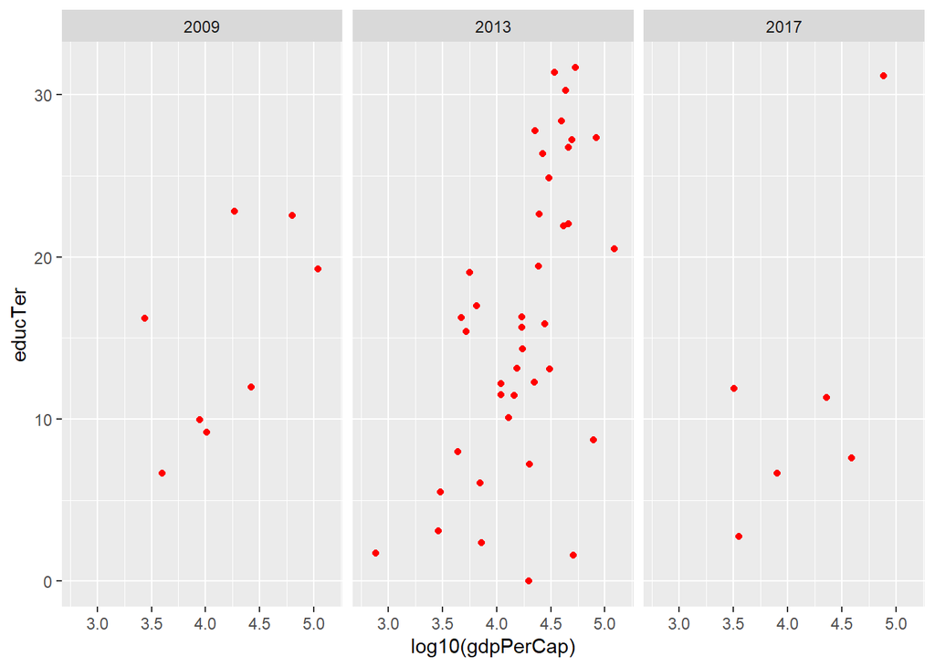

```r
ggplot(data = df_late, aes(x = log10(gdpPerCap), y = educTer)) +
    geom_point(color = "red") +
    facet_wrap(~factor(year))
```

This sort of thing allows us to distinguish between two different scatter plots, for example.

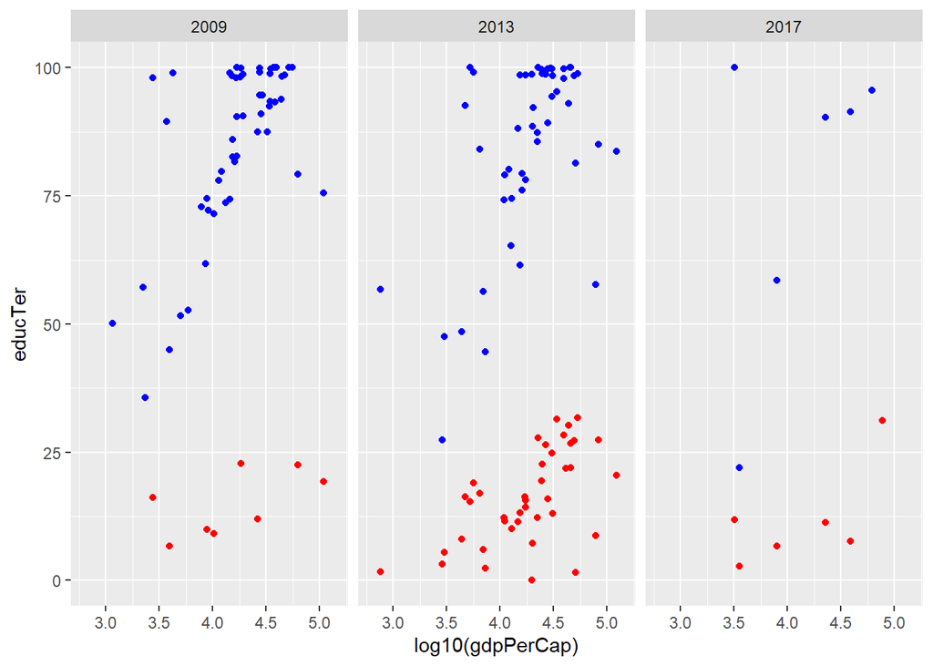

```r
ggplot(data = df_late, aes(x = log10(gdpPerCap))) +
    geom_point(data = df_late, aes(y = educTer), color = "red") +
    geom_point(data = df_late, aes(y = educPri), color = "blue") +
    facet_wrap(~factor(year))
```

As a warning, this is not best practice, and it is extremely awkward to make a legend for this kind of incantation! Later in the course, we’ll see the more principled way to do this.